# R Notebook

### Question 1

```r
leukemia = read.csv("leukemia.csv")
y = as.factor(leukemia$class)
X = as.matrix(leukemia[, -1])
```

**Logistic regression with lasso and ridge penalty**

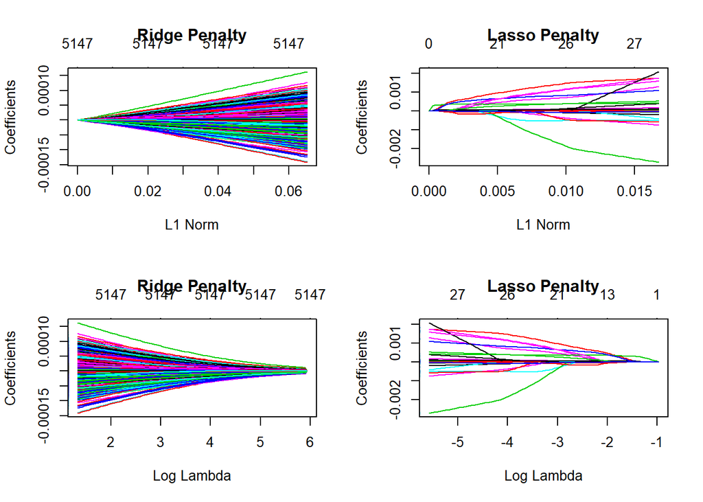

```r
set.seed(657853292)

log_ridge = glmnet(X, y, family = "binomial", alpha = 0)
set.seed(657853292)
log_lasso = glmnet(X, y, family = "binomial", alpha = 1)

par(mfrow = c(2, 2))
plot(log_ridge, main = "Ridge Penalty")
plot(log_lasso, main = "Lasso Penalty")

plot(log_ridge, xvar = "lambda", label = TRUE, , main = "Ridge Penalty")
plot(log_lasso, xvar = "lambda", label = TRUE, , main = "Lasso Penalty")
```

**tuning logistic regression with lasso penalty with 5 fold CV**

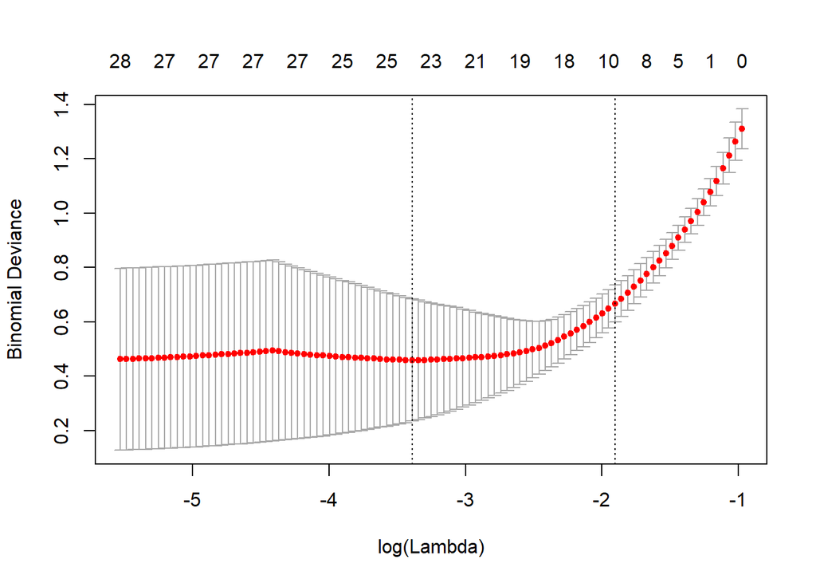

```r
par(mfrow = c(1, 1))
set.seed(657853292)
fit_lasso_cv = cv.glmnet(X, y, alpha = 1, family = "binomial", nfolds = 5)
plot(fit_lasso_cv)
```

```r
lambda_min_dev = fit_lasso_cv$lambda.min
lambda_1se = fit_lasso_cv$lambda.1se

set.seed(657853292)
cv_5 = trainControl(method = "cv", number = 5)
lasso_grid = expand.grid(alpha = 1,
                         lambda = c(lambda_min_dev, lambda_1se))

fit_lasso = train(
  class ~ .,
  data = leukemia,
  method = "glmnet",
  trControl = cv_5,
  tuneGrid = lasso_grid
)

lasso_accuracy = fit_lasso$results[, c("Accuracy", "AccuracySD")]
```

**tuning logistic regression with ridge penalty with 5 fold CV**

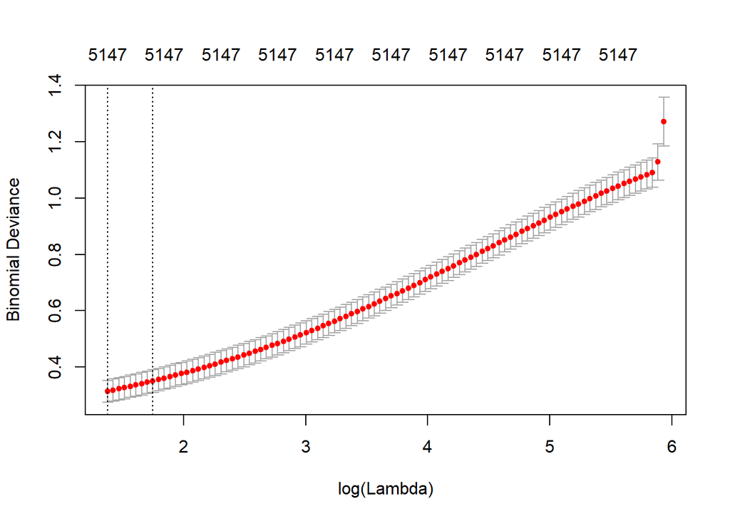

```r
par(mfrow = c(1, 1))
set.seed(657853292)
fit_ridge_cv = cv.glmnet(X, y, alpha = 0, family = "binomial", nfolds = 5)
plot(fit_ridge_cv)
```

```r
lambda_min_dev_ridge = fit_ridge_cv$lambda.min
lambda_1se_ridge = fit_ridge_cv$lambda.1se

set.seed(657853292)
ridge_grid = expand.grid(alpha = 0,
                         lambda = c(lambda_min_dev_ridge, lambda_1se_ridge))

fit_ridge = train(
  class ~ .,
  data = leukemia,
  method = "glmnet",
  trControl = cv_5,
  tuneGrid = ridge_grid
)

ridge_accuracy = fit_ridge$results[, c("Accuracy", "AccuracySD")]
```

**tuning knn with 5 fold CV**

```r
set.seed(657853292)
knn_scaled = train(
  class ~ .,
  data = leukemia,
  method = "knn",
  trControl = cv_5,
  preProcess = c("center", "scale")
)

knitr::kable(knn_scaled$results, align = "c")
```

| k | Accuracy | Kappa | AccuracySD | KappaSD |
| --- | --- | --- | --- | --- |
| 5 | 0.8752381 | 0.6865537 | 0.0907515 | 0.2347886 |
| 7 | 0.8619048 | 0.6514660 | 0.0847833 | 0.2182580 |
| 9 | 0.8476190 | 0.6189079 | 0.0572420 | 0.1567408 |

```r
knn_accuracy = knn_scaled$results[, c("Accuracy", "AccuracySD")]
```

**Printing out Result**

```r
res = rbind(lasso_accuracy, ridge_accuracy)
res = rbind(res, knn_accuracy)
res = cbind(Name=c("Lasso minimum deviation", "Lasso 1 std", "Ridge minimum deviation", "Ridge 1 std", "knn k=5", "knn k=7", "knn k=9"), res)

knitr::kable(res, align = "c")
```

| Name | Accuracy | AccuracySD |
| --- | --- | --- |
| Lasso minimum deviation | 0.9600000 | 0.0596285 |
| Lasso 1 std | 0.9323810 | 0.0816774 |
| Ridge minimum deviation | 0.9866667 | 0.0298142 |
| Ridge 1 std | 0.9866667 | 0.0298142 |
| knn k=5 | 0.8752381 | 0.0907515 |
| knn k=7 | 0.8619048 | 0.0847833 |
| knn k=9 | 0.8476190 | 0.0572420 |

### Question 2

**Create functions for getting bestmodel from caret and calculating rmse**

```r
get_best_result = function(caret_fit) {
  best = which(rownames(caret_fit$results) == rownames(caret_fit$bestTune))
  best_result = caret_fit$results[best, ]
  rownames(best_result) = NULL
  best_result
}

calc_rmse = function(actual, predicted) {
  sqrt(mean((actual - predicted) ^ 2))
}
```

**Creating train-test split from College data**

```r
set.seed(42)
index = createDataPartition(College$Outstate, p = 0.75, list = FALSE)
college_trn = College[index, ]
college_tst = College[-index, ]
```

**Creating required models using Caret package**

```r
model_name = "lm"
set.seed(657853292)
lm_model = train(
  Outstate ~ .,
  data = college_trn,
  method = "lm",
  trControl = cv_5
)

cv_rmse = lm_cv_rmse = min(lm_model$results$RMSE)
test_rmse = calc_rmse(college_tst$Outstate, predict(lm_model, college_tst))
knitr::kable(get_best_result(lm_model))
```

| intercept | RMSE | Rsquared | MAE | RMSESD | RsquaredSD | MAESD |
| --- | --- | --- | --- | --- | --- | --- |
| TRUE | 1997.408 | 0.7596067 | 1574.618 | 121.052 | 0.0326127 | 120.9047 |

```r
model_name = c(model_name, "elastic net")
set.seed(657853292)
el_model1 = train(
  Outstate ~ .,
  data = college_trn,
  method = "glmnet",
  trControl = cv_5,
  tuneLength = 10
)

cv_rmse = c(cv_rmse, min(el_model1$results$RMSE))
test_rmse = c(test_rmse, calc_rmse(college_tst$Outstate, predict(el_model1, college_tst)))
knitr::kable(get_best_result(el_model1))
```

| alpha | lambda | RMSE | Rsquared | MAE | RMSESD | RsquaredSD | MAESD |
| --- | --- | --- | --- | --- | --- | --- | --- |
| 0.8 | 15.54481 | 1988.04 | 0.7616889 | 1566.114 | 119.9096 | 0.0317988 | 109.3878 |

```r
model_name = c(model_name, "elastic net interactions")
set.seed(657853292)
el_model2 = train(
  Outstate ~ .^2,
  data = college_trn,
  method = "glmnet",
  trControl = cv_5,
  tuneLength = 10
)

cv_rmse = c(cv_rmse, min(el_model2$results$RMSE))
test_rmse = c(test_rmse, calc_rmse(college_tst$Outstate, predict(el_model2, college_tst)))
knitr::kable(get_best_result(el_model2))
```

| alpha | lambda | RMSE | Rsquared | MAE | RMSESD | RsquaredSD | MAESD |
| --- | --- | --- | --- | --- | --- | --- | --- |
| 0.2 | 95.60161 | 1864.721 | 0.791301 | 1439.126 | 116.4536 | 0.0458777 | 69.17162 |

```r
model_name = c(model_name, "knn")
set.seed(657853292)
knn_model1 = train(
  Outstate ~ .,
  data = college_trn,
  method = "knn",
  trControl = cv_5,
  preProcess = c("center", "scale")
)

cv_rmse = c(cv_rmse, min(knn_model1$results$RMSE))
test_rmse = c(test_rmse, calc_rmse(college_tst$Outstate, predict(knn_model1, college_tst)))
knitr::kable(get_best_result(knn_model1))
```

| k | RMSE | Rsquared | MAE | RMSESD | RsquaredSD | MAESD |
| --- | --- | --- | --- | --- | --- | --- |
| 7 | 1870.69 | 0.7943264 | 1436.007 | 172.4426 | 0.0462891 | 106.8431 |

```r
model_name = c(model_name, "knn interactions")
set.seed(657853292)
knn_model2 = train(
  Outstate ~ .^2,
  data = college_trn,
  method = "knn",
  trControl = cv_5,
  preProcess = c("center", "scale")
)

cv_rmse = c(cv_rmse, min(knn_model2$results$RMSE))
test_rmse = c(test_rmse, calc_rmse(college_tst$Outstate, predict(knn_model2, college_tst)))
knitr::kable(get_best_result(knn_model2))
```

| k | RMSE | Rsquared | MAE | RMSESD | RsquaredSD | MAESD |
| --- | --- | --- | --- | --- | --- | --- |
| 9 | 1937.045 | 0.7794664 | 1478.095 | 171.4817 | 0.0346815 | 98.74542 |

**Print out model summaries**

```r
res2 = cbind(model_name, cv_rmse)
res2 = cbind(res2, test_rmse)
knitr::kable(res2, align = "c")
```

[output not shown]

## Question 3

### Leukemia

1. How many observations are in the dataset? How many predictors are in the dataset?

**number of observations = 72** **nunmber of predictors = 5147**

2. Based on the deviance plots, do you feel that glmnet considered enough $\lambda$ values for lasso?

**Yes because we can locate a local minima of the error**

*(c) Based on the deviance plots, do you feel that glmnet considered enough $\lambda$ values for ridge?*

**No because we cannot locate a local minima of the error**

4. How does k-nearest neighbor compare to the penalized methods? Can you explain any difference?

**k-nearest models are performing poorly compared to the lasso or ridge penalized models because of two reasons:** **- Compared to Lasso is performs worst because of the curse of dimensionality, knn considers all the variables even the unimportant ones but lasso picks the most important variables .ie. it uses a subset of the total number of variables.** **- Compared to ridge it performs worst because in ridge regularization happens which prevents the model from over fitting.**

5. Based on your results, which model would you choose? Explain.

**Based on the results, ridge regression with minimum standard deviation as it is performing best as well as it’s variance is less**

### College

6. Based on the table, which model do you prefer? Justify your answer.

7. For both of the elastic net models, report the best tuning parameters from caret. For each, is this ridge, lasso, or somewhere in between? If in between, closer to which?

**alpha=0.8 and lambda=15.54 for elastic-net without interaction. This is closer to lasso but not exactly lasso**

8. Did you scale the predictors when you used KNN? Should you have scaled the predictors when you used KNN?

**Yes, the model is performing better with scaling. Yes it is recommended to scale the predictors when using knn because in knn we measure the distances between pairs of samples and these distances are influenced by the measurement units also. Example if we just have 3 predictors, three of the predictors lie between 0 and 1, and the third predictor ranges from 0 to 10000. The third predictor is going to dominate the euclidian distance between the points thus we will miss a lot of information from the first 2 predictors.**

1. Of the two KNN models which works better? Can you explain why?

**kNN model without interaction works better since its test rmse is lesser. This is because when we are having interactions the number of predictors increases and since knn is based on the distance between the points the higher dimensional space of the predictors more difficult it gets for knn to predict correctly. Also known as curse of dimensionalty**

10. What year is this dataset from? What was out-of-state tuition at UIUC at that time?

**Year of the dataset is 1995. The out of state tuition for UIUC at that time was USD$7560**